# BIOSTAT-M280: Homework #2

Due Feb 15 @ 11:59PM

Darrick Shen (UID:604946049)

## 7.3.4 Exercises:

1. Explore the distribution of each of the x, y, and z variables in diamonds. What do you learn? Think about a diamond and how you might decide which dimension is the length, width, and depth.

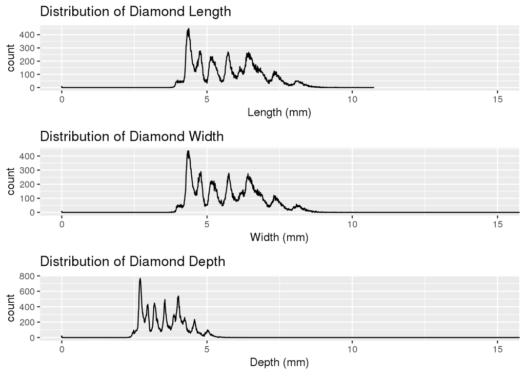

   ```r
   ggplot(data = diamonds, mapping = aes(x = x)) +
     geom_freqpoly(binwidth = 0.01) + coord_cartesian(xlim = c(0, 15)) +
     xlab("Length (mm)") + ggtitle("Distribution of Diamond Length") -> p1

   ggplot(data = diamonds, mapping = aes(x = y)) +
     geom_freqpoly(binwidth = 0.01) + coord_cartesian(xlim = c(0, 15)) +
     xlab("Width (mm)") + ggtitle("Distribution of Diamond Width") -> p2

   ggplot(data = diamonds, mapping = aes(x = z)) +
     geom_freqpoly(binwidth = 0.01) + coord_cartesian(xlim = c(0, 15)) +
     xlab("Depth (mm)") + ggtitle("Distribution of Diamond Depth") -> p3

   multiplot(p1, p2, p3, cols = 1)
   ```

   The plot for z shows measurements significantly shorter than those found in x and y, while x and y both look to be distributed very similarly. y and z both appear to have outliers, as evidenced by the continuing line throughout the end of the graph, whereas the plot for x appears to stop abruptly, shortly after ~10. It makes sense to conclude that z is depth, as diamonds are expected to be both longer and wider than deep. For the sake of consistency, **for the rest of the report we will refer to x as length, and y as width** (but based soley on distributions, it could very well be vice versa, as it is hard to distinguish between the two).
2. Explore the distribution of price. Do you discover anything unusual or surprising? (Hint: Carefully think about the binwidth and make sure you try a wide range of values.

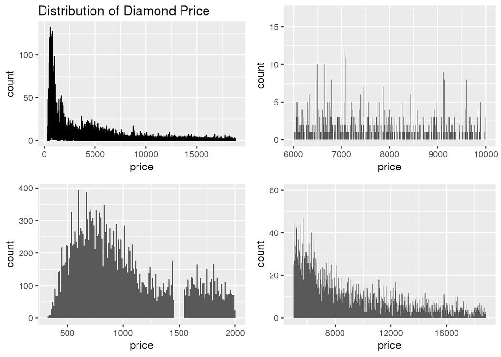

   ```r
     # Plot of the entire distribution shows an unusual bump around ~8000.
   ggplot(data = diamonds, mapping = aes(x = price)) +
     geom_freqpoly(binwidth = 1) +
     ggtitle("Distribution of Diamond Price") -> p1

     # Filter for prices under 2000 and discover a lapse in diamonds priced ~1500.
   lower <- diamonds %>%
     filter(price < 2000)
   ggplot(data = lower, mapping = aes(x = price)) +
     geom_histogram(binwidth = 10) -> p2

     # Filter for prices between 6000 and 10000.
   bigger <- diamonds %>%
     filter(price < 10000 & price > 6000)
   ggplot(data = bigger, mapping = aes(x = price)) +
     geom_histogram(binwidth = 1) -> p3

     # Filter for prices over 5000.
   upper <- diamonds %>%
     filter(price > 5000)
   ggplot(data = upper, mapping = aes(x = price)) +
     geom_histogram(binwidth = 10) -> p4

   multiplot(p1, p2, p3, p4, cols = 2)
   ```

   We notice generally that diamond prices are distributed in a negative exponential fashion. The top left graph shows a slight bump in diamonds priced around ~8000 dollars. The lower left graph shows an unusual absence of diamonds priced near ~1500 dollars.
3. How many diamonds are 0.99 carat? How many are 1 carat? What do you think is the cause of the difference?

   ```r
   unusual <- diamonds %>%
     filter(carat == 0.99 | carat == 1.00) %>%
     count(carat)
   unusual
   ```

   ```
   ## # A tibble: 2 x 2
   ##   carat     n
   ##   <dbl> <int>
   ## 1 0.990    23
   ## 2 1.00   1558
   ```

   There are 1558 observed 1.00 carat diamonds, compared to 23 observed 0.99 carat diamonds. That is almost 68 times more 1.00 carat diamonds than 0.99 carat diamonds. There is likely a big price increase in diamond pricing once they hit the 1.00 carat threshold, leading to upwards rounding at 0.99. 1.00 carat simply sounds better than 0.99 and may lead to customers being more susceptible to purchasing 1.00 carat diamonds over 0.99 carat diamonds, since the price difference is negligible.
4. Compare and contrast coord_cartesian() vs xlim() or ylim() when zooming in on a histogram. What happens if you leave binwidth unset? What happens if you try and zoom so only half a bar shows?

   ```
   ## Warning: Removed 26050 rows containing non-finite values (stat_bin).
   ```

   ```
   ## Warning: Removed 1 rows containing missing values (geom_bar).
   ```

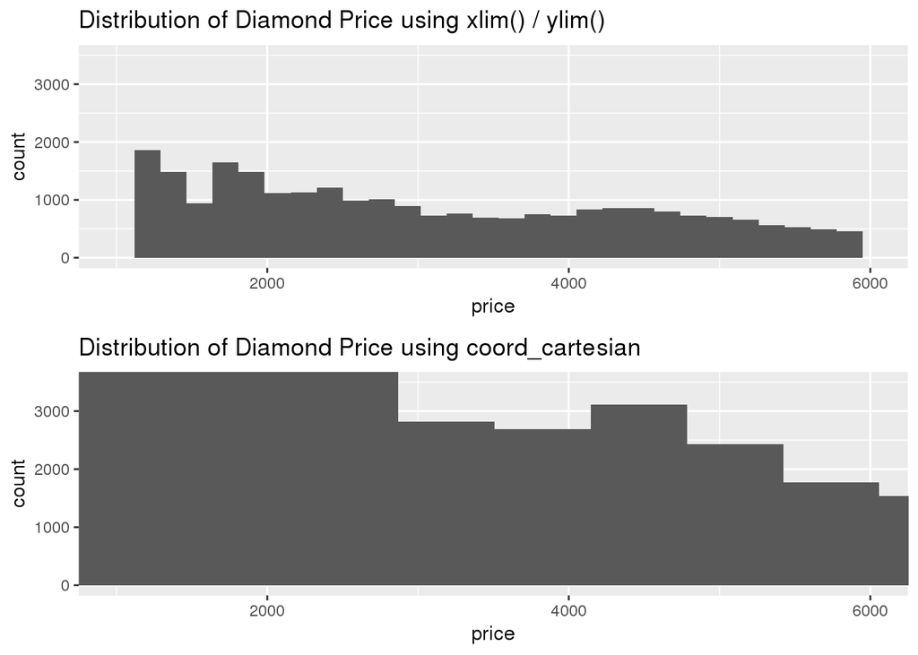

   ```r
     # xlim() or ylim().
   ggplot(diamonds) +
     geom_histogram(mapping = aes(x = price)) +
     xlim(1000, 6000) +
     ylim(0, 3500) +
     ggtitle("Distribution of Diamond Price using xlim() / ylim()") -> p1

     # coord_cartesian()
   ggplot(diamonds) +
     geom_histogram(mapping = aes(x = price)) +
     coord_cartesian(xlim = c(1000, 6000),
                     ylim = c(0, 3500)) +
     ggtitle("Distribution of Diamond Price using coord_cartesian") -> p2

   multiplot(p1, p2, cols = 1)
   ```

   When xlim() and ylim() functions, values outside of the xlim, ylim range are dropped before calculating the histogram. This is why the xlim, ylim plot has a lower count than the coord_cartesian plot. Conversely, cartesian_coord() does not drop any values, and only “zooms” into the limits defined by xlim and ylim. When we do not set the binwidth, we get a message from R that “bins = 30”, and a warning to pick a better binwidth.

   ```
   ## Warning: Removed 53938 rows containing non-finite values (stat_bin).
   ```

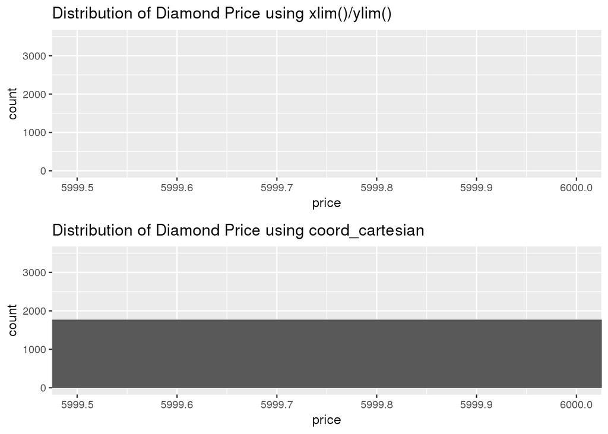

   ```r
     # Example: zooming in very close into a bar/half-bar.
     # xlim() or ylim().
   ggplot(diamonds) +
     geom_histogram(mapping = aes(x = price)) +
     xlim(5999.5, 6000) +
     ylim(0, 3500) +
     ggtitle("Distribution of Diamond Price using xlim()/ylim()") -> p1
     # coord_cartesian().
   ggplot(diamonds) +
     geom_histogram(mapping = aes(x = price)) +
     coord_cartesian(xlim = c(5999.5, 6000), ylim = c(0, 3500)) +
     ggtitle("Distribution of Diamond Price using coord_cartesian") -> p2
   multiplot(p1, p2, cols = 1)
   ```

   This example shows that if you try to zoom into half of a bar using coord_cartesian, you will see a solid block along the x-values, at the appropriate counts. Whereas, using the xlim() and ylim() functions alone, you will see an empty plot because values outside of the specific price range (in this case 5999.5-6000) will be dropped before calculating– effectively dropping all the values– and drawing the histogram. Resultingly the first plot is an empty plot.

## 7.4.1:

1. What happens to missing values in a histogram? What happens to missing values in a bar chart? Why is there a difference?

   ```
   ## Warning: Removed 9 rows containing non-finite values (stat_bin).
   ```

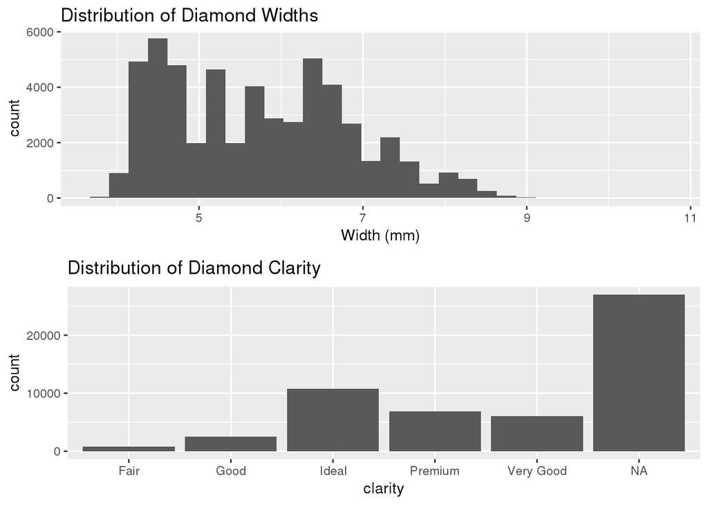

   ```r
      # Creating a subset from diamonds, removing lower and upper length.
   diamondMidWidth <- diamonds %>%
     mutate(y = ifelse(y < 3 | y > 20, NA, y))
   ggplot(diamondMidWidth) +
     geom_histogram(mapping = aes(x = y)) +
     xlab("Width (mm)") +
     ggtitle("Distribution of Diamond Widths") -> p1

     # Creating a subset from
   n <- nrow(diamonds)
   diamondMidClarity <- diamonds %>%
     mutate(clarity = if_else(rnorm(n) < 0.0001, NA_character_,
                              as.character(cut)))
   ggplot(diamondMidClarity) +
     geom_bar(mapping = aes(x = clarity)) +
     ggtitle("Distribution of Diamond Clarity") -> p2

   multiplot(p1, p2, cols = 1)
   ```

   When attempting to plot a subset of diamond widths(y) with missing values(NA), the missing values are first removed, before the number of observations in each bin is calculated. There will be a warning message that alerts you “Removed # rows containing non-finite values (stat_bin)”. When using geom_bar to plot a subset of categorical data, DiamondMidClarity, the “NA” values are treated as another gradation, so to speak, of clarity and are subsequently plotted as another category in the bar plot seen above. The reason for this difference is because histograms use continuous quantitative variables on the x-axis, while bar charts position categorical variables over the x-axis. For histograms, it would not make sense to include NA values on a numeric scale.
2. What does na.rm = TRUE do in mean() and sum()?

   ```r
     # Creating a vector of random variables and inserting NA values.
   ranVals <- rnorm(n = 100, mean = 10, sd = 10)
     # In this case, which elements of (ranVals %in% sample) are TRUE:
     # and randomly chooses 20 indices to be replaced with NA.
   miss <- which(ranVals %in% sample(ranVals, 20))
   ranVals[miss] <- NA

   mean(ranVals, na.rm = FALSE)
   ```

   ```
   ## [1] NA
   ```

   ```r
   sum(ranVals, na.rm = FALSE)
   ```

   ```
   ## [1] NA
   ```

   ```r
   mean(ranVals, na.rm = TRUE)
   ```

   ```
   ## [1] 11.20282
   ```

   ```r
   sum(ranVals, na.rm = TRUE)
   ```

   ```
   ## [1] 896.2257
   ```

   When attempting to calculate the mean or sum of a vector with NA values, the result is NA. If we utilize na.rm = TRUE, the NA observations are ommitted from the calculation, allowing us to have a numerical answer.

## 7.5.1.1:

1. Use what you’ve learned to improve the visualisation of the departure times of cancelled vs. non-cancelled

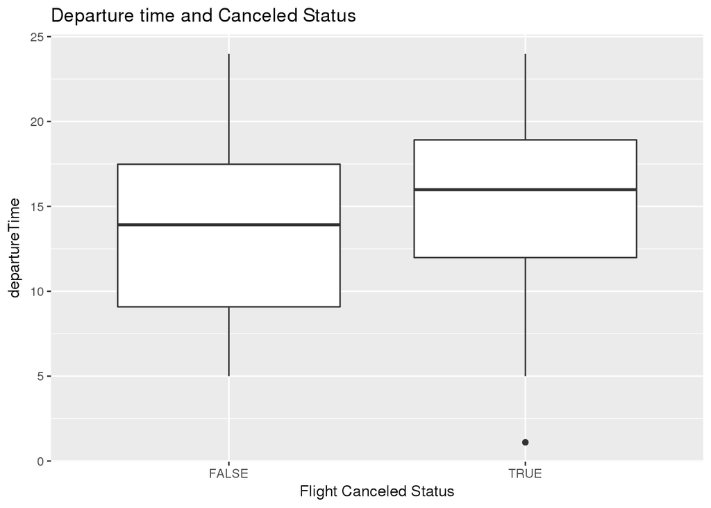

   ```r
   flightSub <- nycflights13::flights %>%
     # Subsetting canceled flights if departure time is NA.
   mutate(canceledFlight = is.na(dep_time),
            # Calculating military time (24 hour scale).
          min = (sched_dep_time %% 100) / 60,
          hour = sched_dep_time %/% 100,
          departureTime = hour + min
          ) %>%
   ggplot() + ggtitle("Departure time and Canceled Status") +
     geom_boxplot(mapping = aes(y = departureTime, x = canceledFlight)) +
     xlab("Flight Canceled Status")
   flightSub
   ```

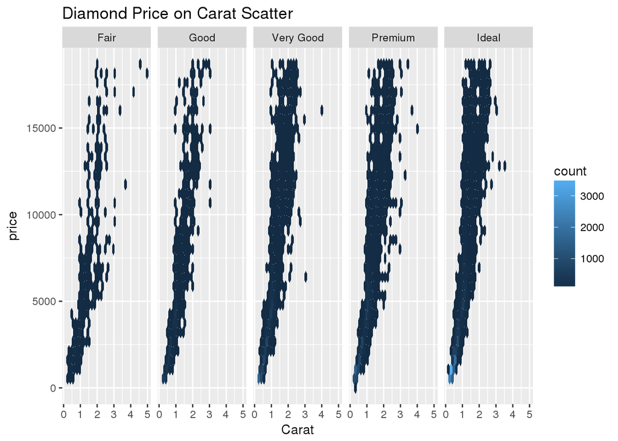

   ```r
     # We will plot the variables of interest of diamonds, against price, to see if we can spot a strong correlation.
   ggplot(diamonds, aes(x = carat, y = price)) +
     geom_hex() +
     ggtitle("Diamond Price on Carat Scatter") +
     xlab("Carat") +
     facet_wrap(~cut, ncol = 5)
   ```

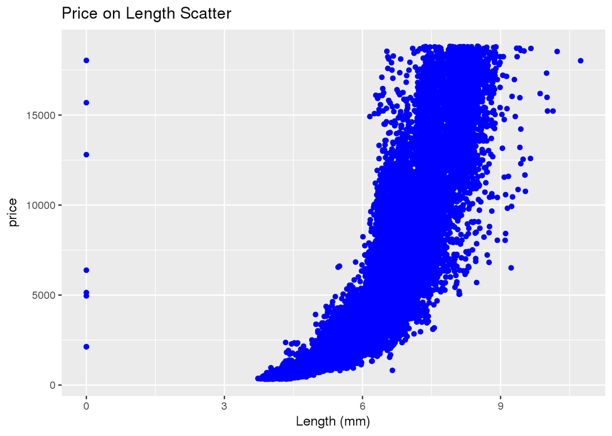

   ```r
   ggplot(diamonds) +
     geom_point(aes(x = x, y = price), colour = "blue") +
     ggtitle("Price on Length Scatter") +
     xlab("Length (mm)")
   ```

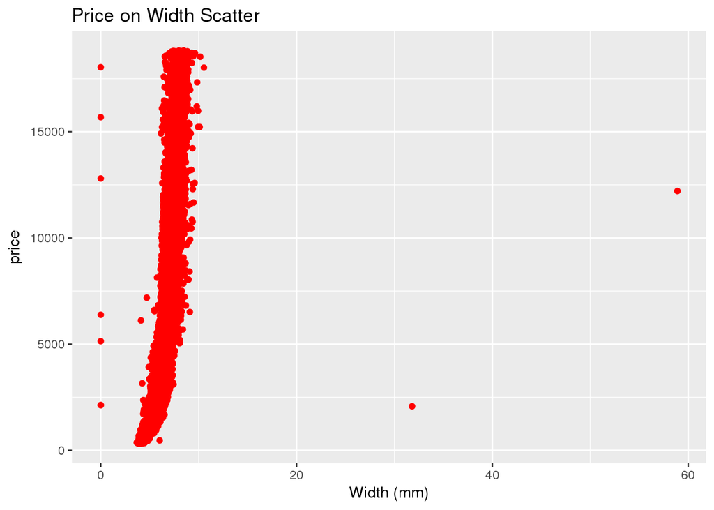

   ```r
   ggplot(diamonds) +
     geom_point(aes(x = y, y = price), colour = "red") +
     ggtitle("Price on Width Scatter") +
     xlab("Width (mm)")
   ```

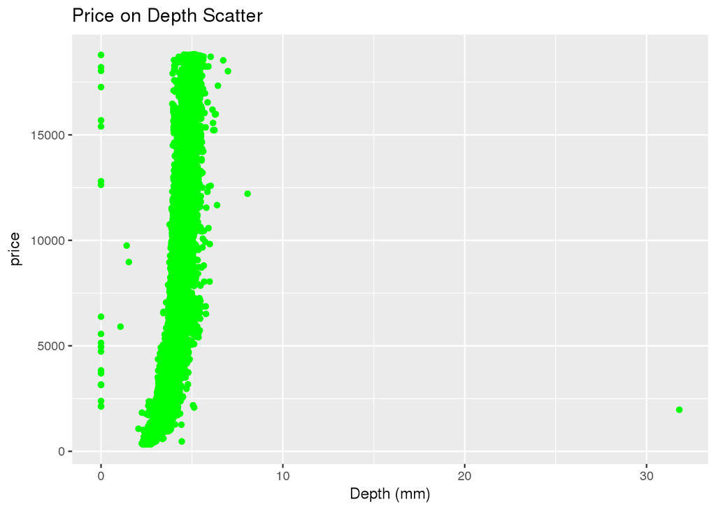

   ```r
   ggplot(diamonds) +
     geom_point(aes(x = z, y = price), colour = "green") +
     ggtitle("Price on Depth Scatter") +
     xlab("Depth (mm)")
   ```

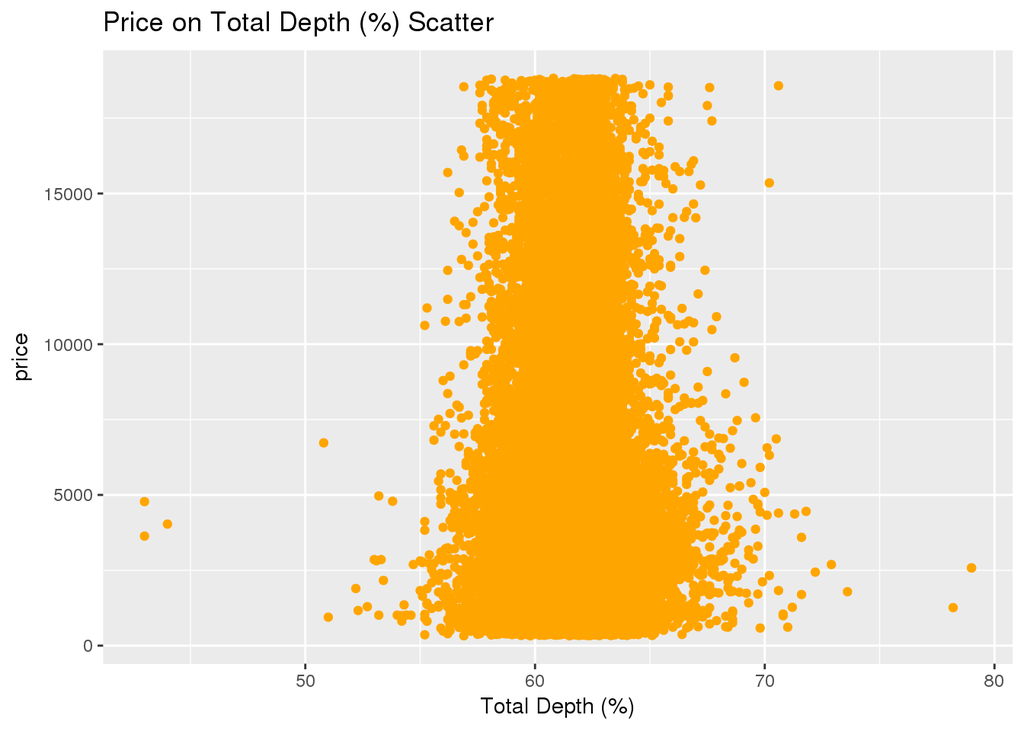

   ```r
   ggplot(diamonds) +
     geom_point(aes(x = depth, y = price), colour = "orange") +
     ggtitle("Price on Total Depth (%) Scatter") +
     xlab("Total Depth (%)")
   ```

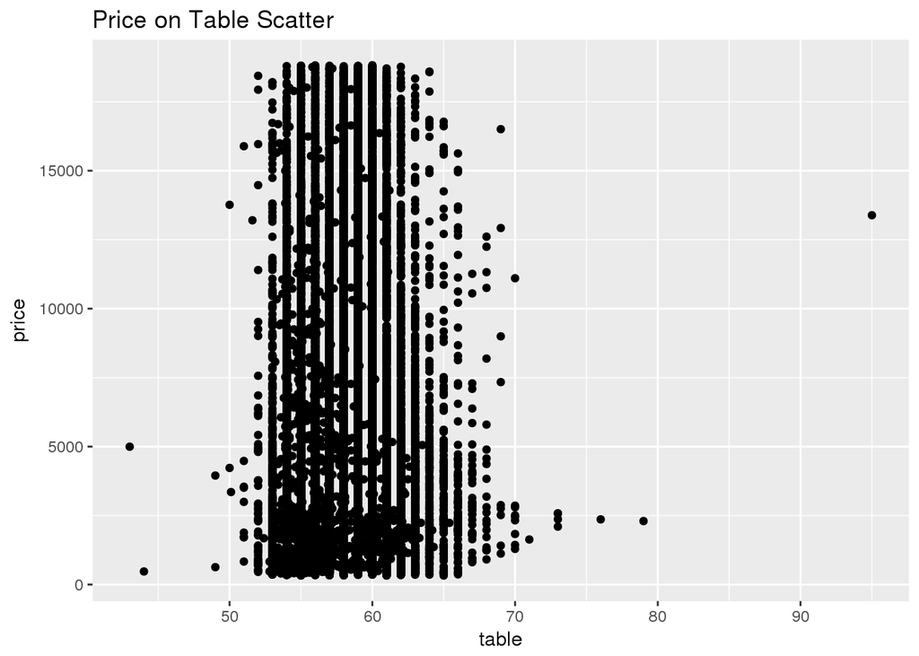

   ```r
   ggplot(diamonds) +
     geom_point(aes(x = table, y = price), colour = "black") +
     ggtitle("Price on Table Scatter") +
     xlab("table")
   ```

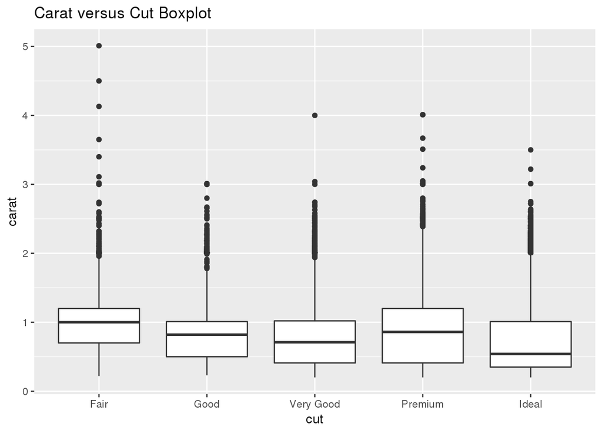

   ```r
     # Carat is significant for predicting price of diamond, so we will try visualizing Carat against cut.
   ggplot(data = diamonds) +
     geom_boxplot(aes(cut, carat)) +
     ggtitle("Carat versus Cut Boxplot")
   ```

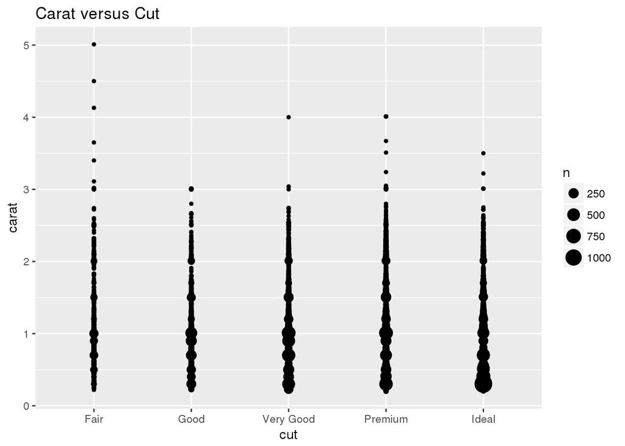

   ```r
   ggplot(data = diamonds) +
     geom_count(mapping = aes(x = cut, y = carat)) +
     ggtitle("Carat versus Cut")
   ```

   ```r
     # Summary statistic showing high correlation between carat and price.
   diamonds %>%
     group_by(cut) %>%
     summarise(cor(carat, price))
   ```

   ```
   ## # A tibble: 5 x 2
   ##   cut       `cor(carat, price)`
   ##   <ord>                   <dbl>
   ## 1 Fair                    0.859
   ## 2 Good                    0.922
   ## 3 Very Good               0.926
   ## 4 Premium                 0.925
   ## 5 Ideal                   0.931
   ```

   The variables Carat, length, width, and depth all appear to be positively correlated to the price of the diamond. However, intuitively, length, width, and depth are all variables that contribute to carat (weight) of the diamond. Thus, it is fair to estimate that Carat has substantial colinearity with the physical dimensions (x, y, z) of the diamond. With the summarise() function we can observe high correlation between carat and price, which increases as cut quality improves. After making a boxplot of carat against cut, we also see that carat is negatively correlated with cut. This makes sense, as it is difficult to find BOTH high carat size and high cut quality, in the same diamond– as this would be the “perfect” diamond. As the carat size increases, the cut quality decreases on average, thereby decreasing the price of the diamond. This leads us to the fact that on average, lower quality cuts, are higher in price, on average.
3. Install the ggstance package, and create a horizontal boxplot. How does this compare to using coord_flip()?

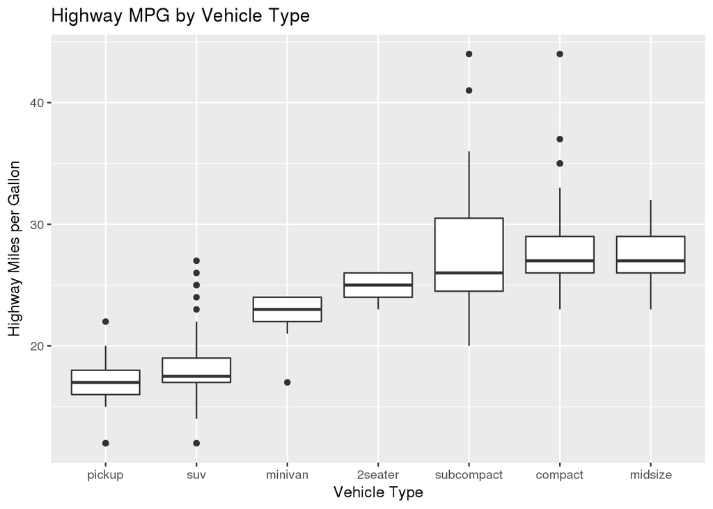

   ```r
   ggplot(data = mpg) +
     geom_boxplot(mapping = aes(x = reorder(class, hwy, FUN = median),
                                y = hwy)) +
     xlab("Vehicle Type") + ylab("Highway Miles per Gallon") +
     ggtitle("Highway MPG by Vehicle Type")
   ```

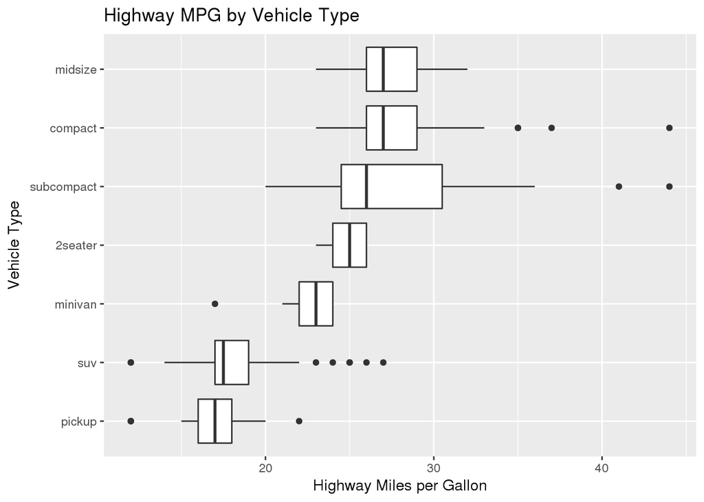

   ```r
     # Usage of coord_flip() function to show vehicle classes on the y axis.
   ggplot(data = mpg) +
     geom_boxplot(mapping = aes(x = reorder(class, hwy, FUN = median),
                                y = hwy)) + coord_flip() +
     xlab("Vehicle Type") + ylab("Highway Miles per Gallon") +
     ggtitle("Highway MPG by Vehicle Type")
   ```

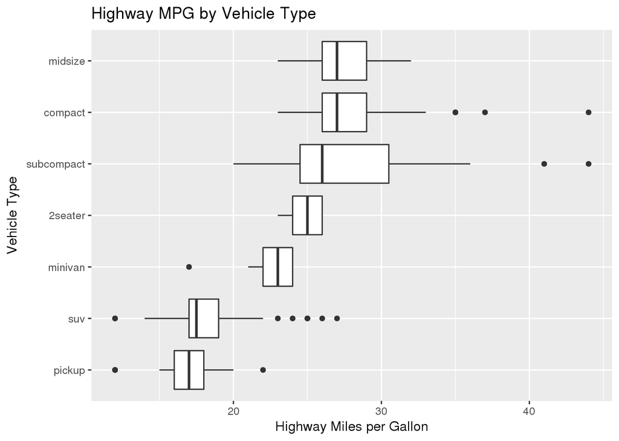

   ```r
     # Usage of ggstance, requires switching the assignment of x and y variables.
   ggplot(data = mpg) +
     geom_boxploth(mapping = aes(x = hwy,
                                 y = reorder(class, hwy, FUN = median))) +
     ylab("Vehicle Type") + xlab("Highway Miles per Gallon") +
     ggtitle("Highway MPG by Vehicle Type")
   ```

   Originally we have the boxplot defined with the classes of vehicles on the x axis, and hwy on the y axis. Thus, when we implement coord_flip, the result is vehicles on the y axis and hwy on the x axis. By installing ggstance and using the function geom_boxploth, to directly plot a horizontal boxplot, we define hwy on the x axis and vehicle classes on the y, to begin with. The plots themselves, in either case are identical– the difference is in defining the x and y varaibles.
4. One problem with boxplots is that they were developed in an era of much smaller datasets and tend to display a prohibitively large number of “outlying values”. One approach to remedy this problem is the letter value plot. Install the lvplot package, and try using geom_lv() to display the distribution of price vs cut. What do you learn? How do you interpret the plots?

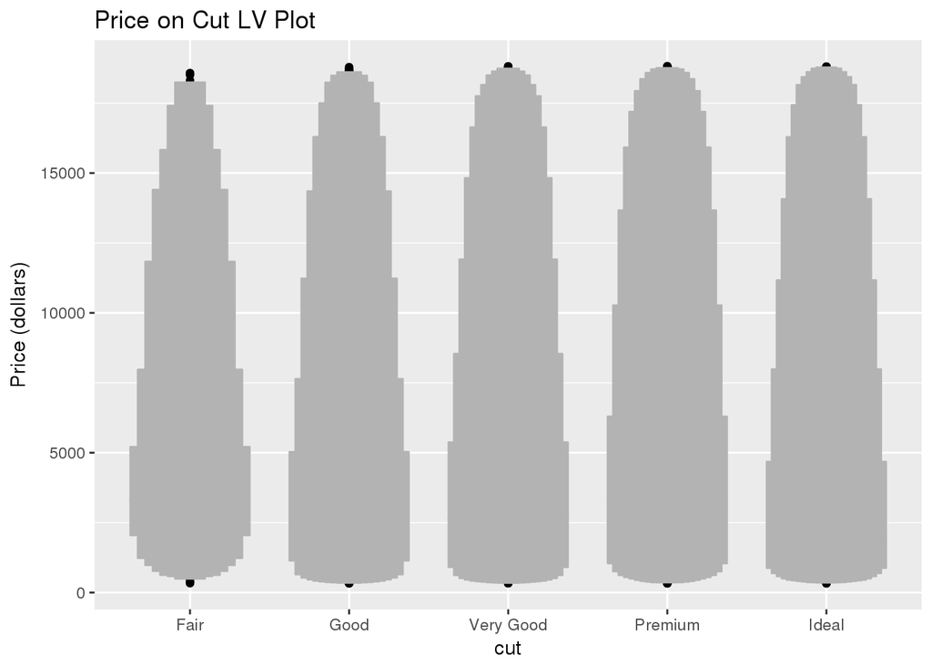

   ```r
   ggplot(diamonds, aes(x = cut, y = price)) +
     ggtitle("Price on Cut LV Plot") +
     ylab("Price (dollars)") +
   geom_lv()
   ```

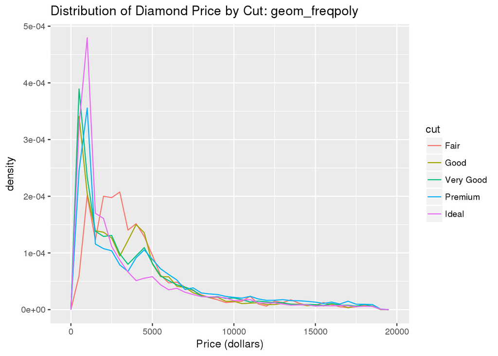

   ```r
   ggplot(data = diamonds,
          mapping = aes(x = price, y = ..density.., colour = cut)) +
     geom_freqpoly(binwidth = 500) + xlab("Price (dollars)") +
     ggtitle("Distribution of Diamond Price by Cut: geom_freqpoly")
   ```

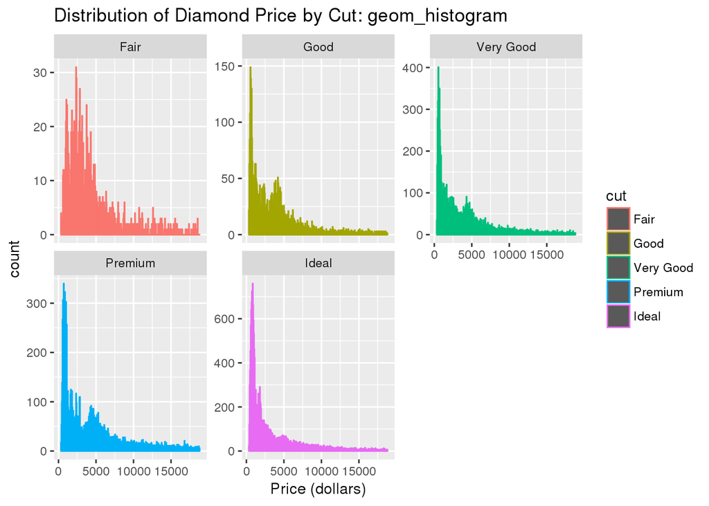

   ```r
   ggplot(data = diamonds, mapping = aes(x = price, colour = cut)) +
     geom_histogram(binwidth = 50) + xlab("Price (dollars)") +
     ggtitle("Distribution of Diamond Price by Cut: geom_histogram") +
     facet_wrap(~cut, scales = "free_y")
   ```

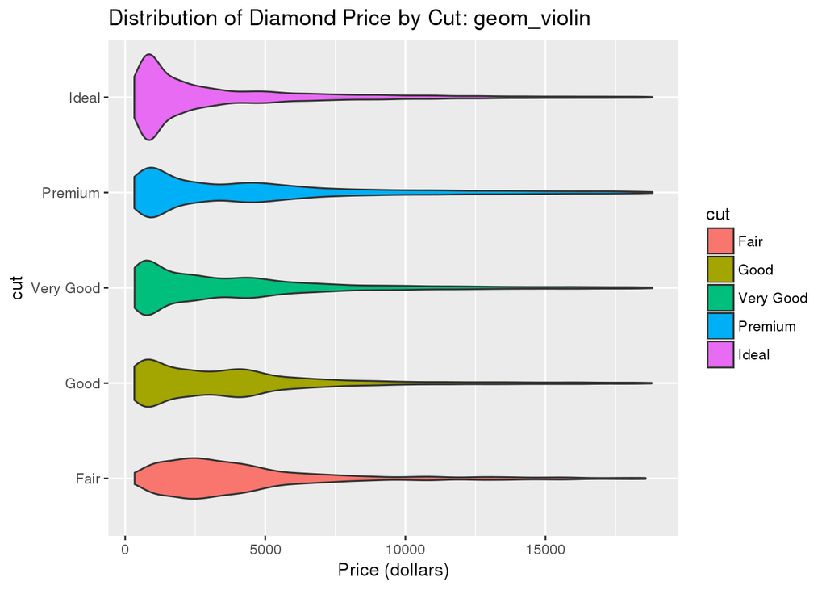

   ```r
   ggplot(data = diamonds, mapping = aes(x = cut, y = price)) +
     geom_violin(aes(fill = cut)) + ylab("Price (dollars)") +
     ggtitle("Distribution of Diamond Price by Cut: geom_violin") +
     coord_flip()
   ```

   Geom_freqpoly allows for easy determination of the highest density of price points for each cut of diamond. However, because the lines are overlapping, it is difficult to say much about individual distributions of cuts, and how they relate or compare to one another. Because each histogram is separated, geom_histogram makes it easy to distinguish between differences in overall shape of distribution, and more specifically: variance and skewness. Similarly, geom_violin is useful for comparing distribution of prices, across cuts, but may not be as easy to immediately compare density of price points.
6. If you have a small dataset, it’s sometimes useful to use geom_jitter() to see the relationship between a continuous and categorical variable. The ggbeeswarm package provides a number of methods similar to geom_jitter(). List them and briefly describe what each one does.

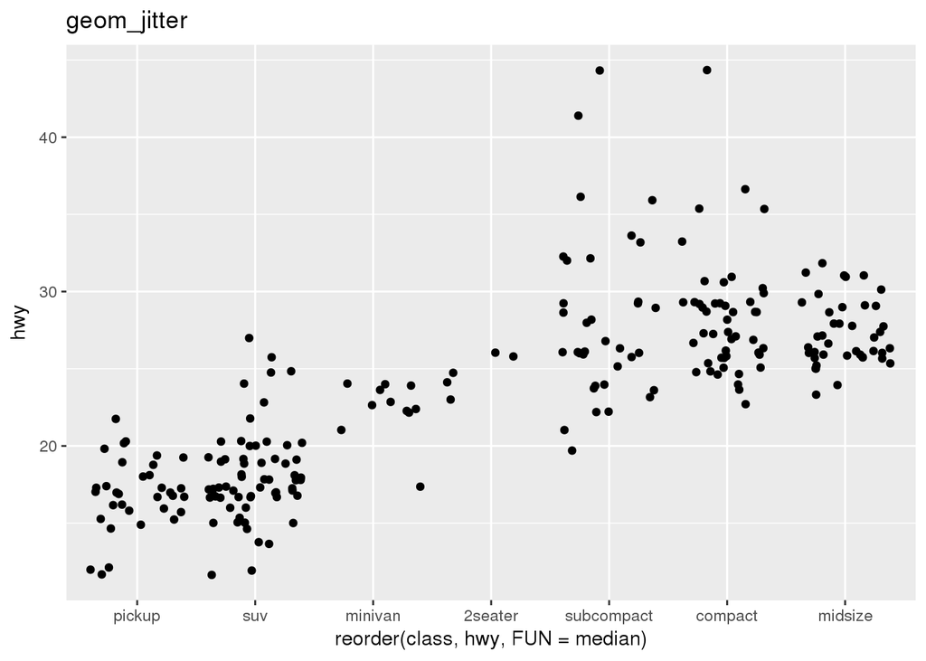

   ```r
   ggplot(data = mpg) +
     geom_jitter(mapping = aes(x = reorder(class, hwy, FUN = median),
                               y = hwy)) +
     ggtitle("geom_jitter")
   ```

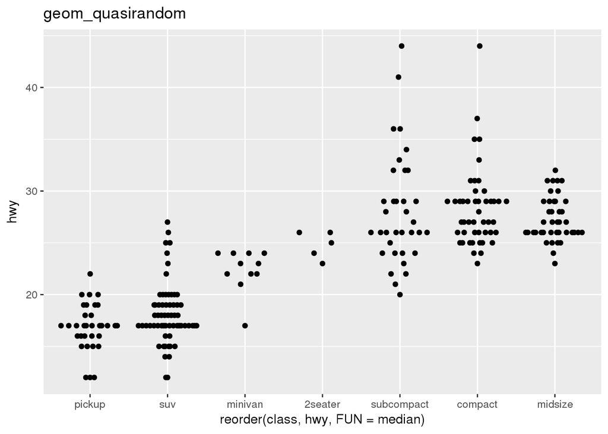

   ```r
   ggplot(data = mpg) +
     geom_quasirandom(mapping = aes(x = reorder(class, hwy, FUN = median),
                                    y = hwy)) +
     ggtitle("geom_quasirandom")
   ```

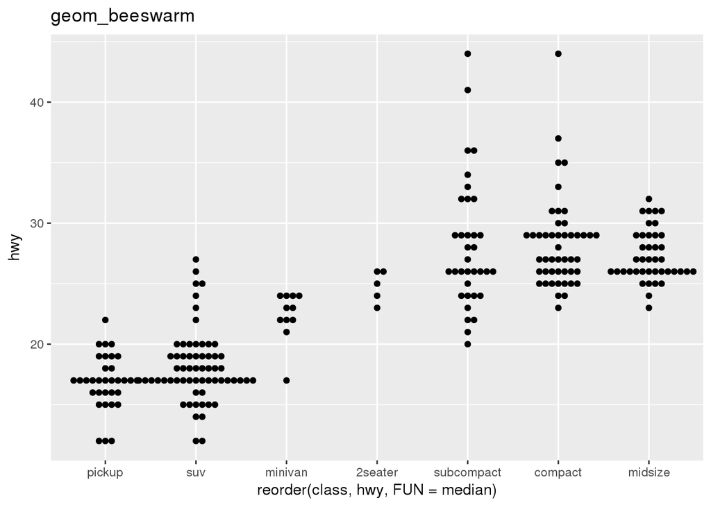

   ```r
   ggplot(data = mpg) +
     geom_beeswarm(mapping = aes(x = reorder(class, hwy, FUN = median),
                                 y = hwy)) +
     ggtitle("geom_beeswarm")
   ```

   Geom_jitter allows us to see the relationship between a continuous and categorical variable by adding a small amount of random variation to each point– handles the overplotting problem created by the discreteness in smaller datasets. Geom_beeswarm is closest in shape (most compact) to geom_violin, with points offset from each other. Geom_quasirandom plots are created with points spaced further away, randomly via different methods including: tukey, tukeyDense, smiley, frowney. In appearance, geom_quasirandom is a jitter/beeswarm hybrid in terms of spacing.

## 7.5.2.1:

1. How could you rescale the count dataset above to more clearly show the distribution of cut within colour, or colour within cut?

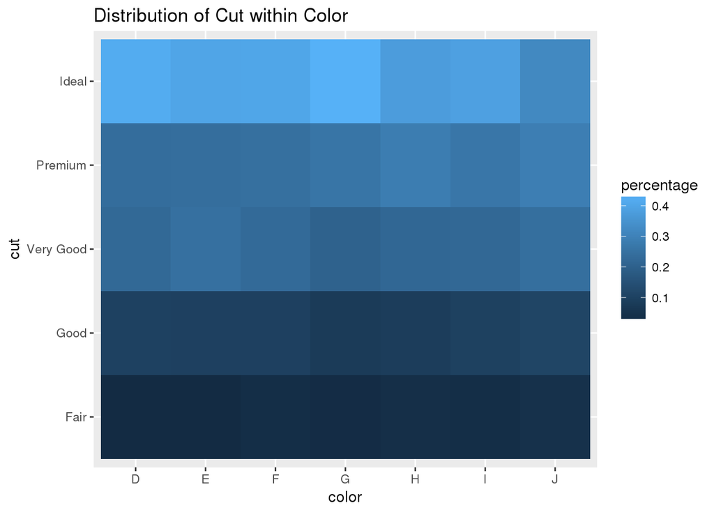

   ```r
     # Cut within Colour.
   diamonds %>%
     count(color, cut) %>%
     group_by(color) %>%
     mutate(percentage = n / sum(n)) %>%
     ggplot(mapping = aes(x = color, y = cut, fill = percentage)) +
     ggtitle("Distribution of Cut within Color") +
     geom_tile()
   ```

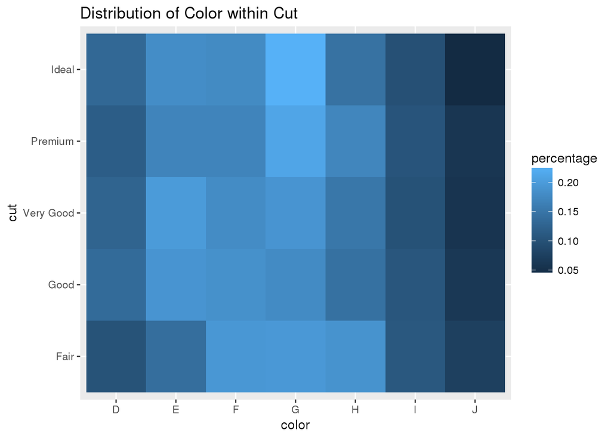

   ```r
     # Colour within Cut.
   diamonds %>%
     count(color, cut) %>%
     group_by(cut) %>%
     mutate(percentage = n / sum(n)) %>%
     ggplot(mapping = aes(x = color, y = cut, fill = percentage)) +
       ggtitle("Distribution of Color within Cut") +
       geom_tile()
   ```

   To better illustrate the distribitions of cut within colour and colour within cut, instead of using counts in the plot, we can calculate the proportion that fall into each color and cut type and plot by proportion to more clearly illustrate distribution category. This standardizes our results, as some categories of diamond colors and cut may have more total coutns than other.
2. Use geom_tile() together with dplyr to explore how average flight delays vary by destination and month of year. What makes the plot difficult to read? How could you improve it?

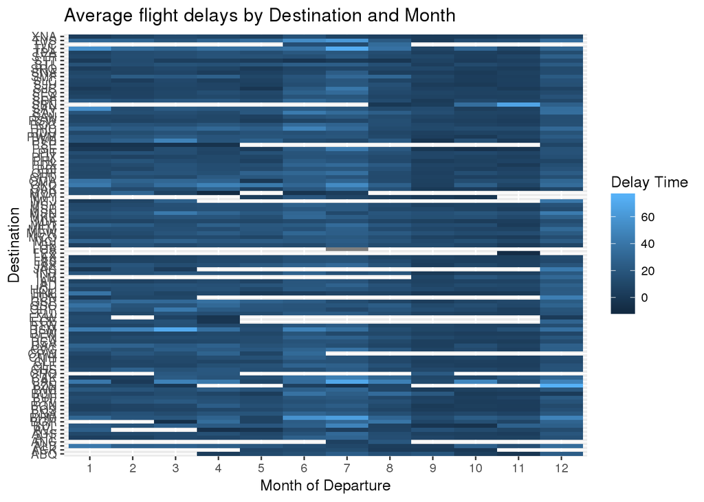

   ```r
   flights %>%
     group_by(dest, month) %>%
     summarise(dep_delay = mean(dep_delay, na.rm = TRUE)) %>%
     ggplot(aes(x = factor(month), y = dest, fill = dep_delay)) +
       geom_tile() +
       ggtitle("Average flight delays by Destination and Month") +
       labs( x = "Month of Departure", y = "Destination", fill = "Delay Time")
   ```

   It is very difficult to interpret this plot because difference between delay times may skew the color distribution. Some sort of required criteria needs to be set for data to be plotted, so that we are not including incomplete data points, with missing values. These missing values for various destinations, between months, contributes to making comparisons difficult.

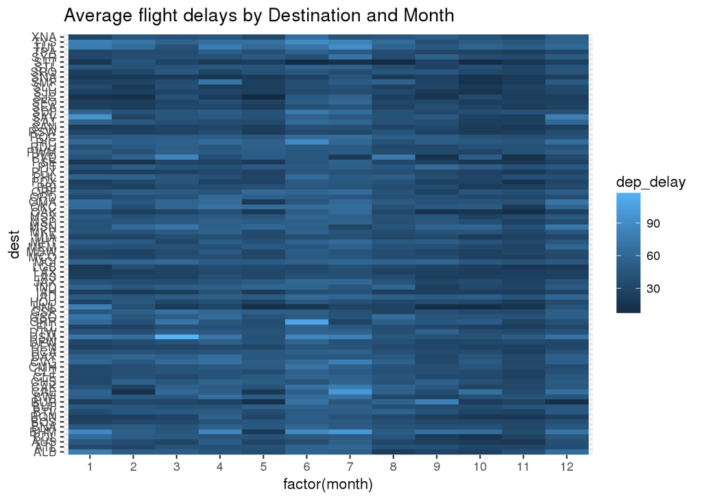

   ```r
     # Here we are ensuring plotted points have a delay in departure AND flights in all 12 months.
   flights %>%
     filter(dep_delay > 0) %>%
     group_by(dest, month) %>%
     summarise(dep_delay = mean(dep_delay, na.rm = TRUE)) %>%
     filter (n() == 12) %>%
     ungroup() %>%
     ggplot(aes(x = factor(month), y = dest, fill = dep_delay)) +
       geom_tile() +
       ggtitle("Average flight delays by Destination and Month")
   ```

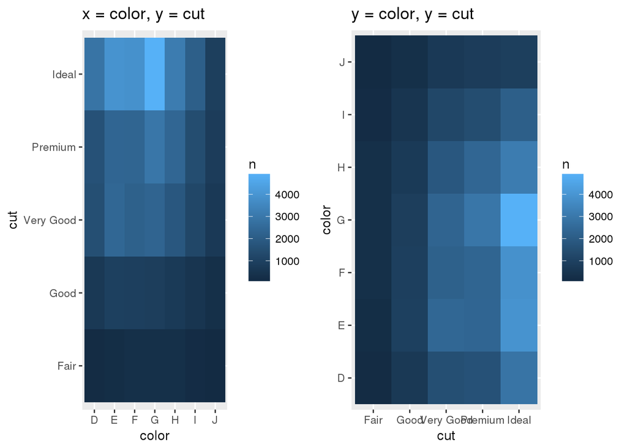

   ```r
     # x = color, y = cut.
   diamonds %>%
     count(color, cut) %>%
     ggplot(mapping = aes(x = color, y = cut)) +
       geom_tile(mapping = aes(fill = n)) +
       ggtitle("x = color, y = cut") -> p1
     # y = color, x = cut.
   diamonds %>%
     count(color, cut) %>%
     ggplot(mapping = aes(x = cut, y = color)) +
       geom_tile(mapping = aes(fill = n)) +
       ggtitle("y = color, y = cut") -> p2

   multiplot (p1, p2, cols = 2)
   ```

   Intuitively, its easier for the audience to interpret the lengthier variable on the y-axis. Further, Cut is an ordered categorical variable, which maybe visually misleading if plotted on the x-axis. When plotting cut on the y-axis, the lighter colors (higher n counts) are towards the top of the plot, which is easier to interpret and is more intuitive than having high n counts at the bottom of the graph. Lastly, longer labels, usually run a lower risk of overlap on the y-axis, compared to the x-axis, as well.

## 7.5.3.1 Exercises

1. Instead of summarising the conditional distribution with a boxplot, you could use a frequency polygon. What do you need to consider when using cut_width() vs cut_number()? How does that impact a visualisation of the 2d distribution of carat and price?

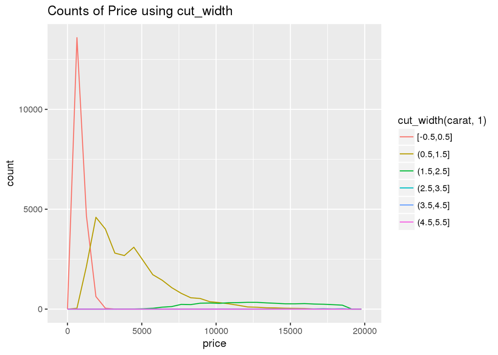

   ```r
         # cut_width to plot count.
       ggplot(data = diamonds,
              mapping = aes(x = price, colour = cut_width(carat, 1))) +
         geom_freqpoly() +
         ggtitle("Counts of Price using cut_width")
   ```

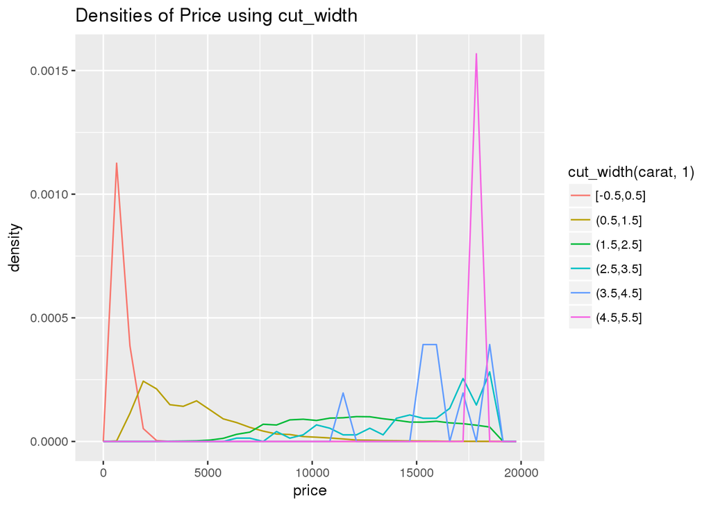

   ```r
         # cut_width to plot density.
       ggplot(data = diamonds,
              mapping = aes(x = price,
                            y = ..density..,
                            colour = cut_width(carat, 1))) +
         geom_freqpoly() +
         ggtitle("Densities of Price using cut_width")
   ```

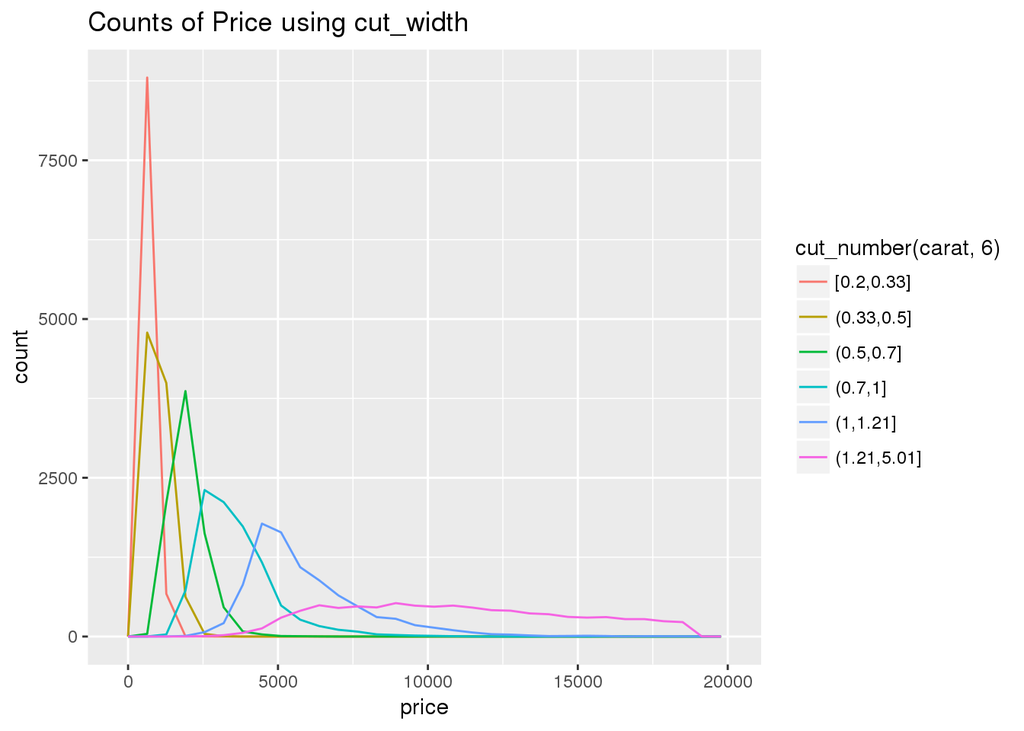

   ```r
         # cut_number to plot count.
       ggplot(data = diamonds,
              mapping = aes(x = price, colour = cut_number(carat, 6))) +
         geom_freqpoly() +
         ggtitle("Counts of Price using cut_width")
   ```